# generate matrix with lags up to k-th order

## Iterative Predictions

Ziel diese kleinen Projektes ist es einen Prognose-workflow aufzubauen, der es erlaubt ML-Algorithmen wie Glmnet oder RandomForest mit Lagged-Predictors aufzusetzen und iterative Prognosen damit zu erstellen. Iterativ bedeutet, dass die prognosewerte für weitere prognosen, die weiter als einen schritt in die zukunft gehen, als regressoren verwendet werden. Das Projekt soll dabei so allgemein gehalten werden, dass es mögich ist, beliebige saiosnalitäten zu verwenden.

Optional sollen die predictions in caret implementiert werden.

## Bausteine

Es wird mit dem paket fpp2, forecast, glmnet und ranger gestartet.

```r
# Pakete Laden
library(fpp2)
library(forecast)
library(glmnet)
library(ranger)

data <- elecdaily

# generate matrix out of vector
# with lags up to the k-th order
gen_lagged_regressors <- function(y = y, lags = 3){
  # y ... matrix or vector
  # k ... lags
  if(is.matrix(y)) y <- as.vector(y)
  if(!(is.vector(y)|is.matrix(y))) stop("y has to be a matrix with one column or a vector")
  n <- length(y)
  mat <- matrix(rep(NA, length.out = length(lags) * n), ncol = length(lags))
  colnames(mat) <- paste0("lag_", lags)
  for(i in seq_along(lags))
    mat[,i] <- c(rep(NA,i),y[-(n:(n-i+1))])
  return(mat)
  }
```

Das ts-format kann dabei nicht verwendet werden, da glmnet und ranger andere formate benötigen. In einem ersten Schritt werden keine Zuküftigen externen regressoren produziert.

```r
lags <- c(1:21)
data <- as.data.frame(data)
data <- cbind(data, gen_lagged_regressors(y = data$Demand, lags = lags))
data <- na.omit(data)

y <- as.matrix(data[,1])
x <- as.matrix(data[,-1])

# train und test
#bis <- floor(.8 * nrow(data))
bis <- 200
tr <- 1:bis
te <- (bis+1):nrow(data)
ytr <- y[tr]
yte <- y[te]
xtr <- x[tr,]
xte <- x[te,]

# fit vanilla cv.glmnet
fit <- cv.glmnet(x = xtr, y = ytr, alpha = .1)

# predict iteratively into testset
predict_ts_cv.glmnet <- function(object, newx, s = "lambda.1se", h, lagvars = paste0("lag_", lags)){
  preds <- numeric(h)
  for(k in 1:h){
    preds[k] <- predict.cv.glmnet(object = object, newx = newx[k,,drop = F], s = s)
    lag_oldx <- newx[k,lagvars]
    if(k<h)
    newx[k+1,lagvars] <- c(preds[k], lag_oldx[-length(lag_oldx)])
  }
  return(preds)
}

# calculate mse
mse <- function(obs, preds){
  mean((obs - preds)^2)
}

preds1 <- predict_ts_cv.glmnet(object = fit, newx = xte, h = nrow(xte), lagvars = paste0("lag_", lags))
```

# plot results

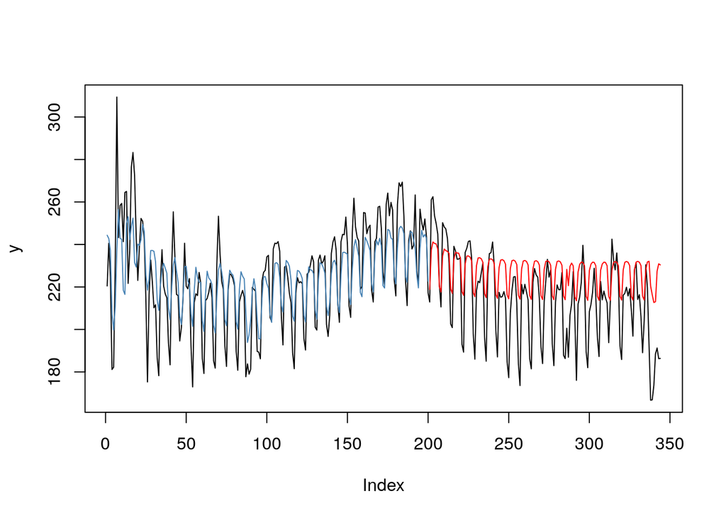

```r
plot(y, type = "l")
lines(predict(fit, newx = xtr, "lambda.1se"), col = "steelblue")
lines(te,preds1, col = "red")
```

# Versuch 2 mit quadratischen termen

```r
y <- as.matrix(data[,1])
data$Temperature_sq <- data$Temperature^2
x <- as.matrix(data[,-1])

# train und test
tr <- 1:bis
te <- (bis+1):nrow(data)
ytr <- y[tr]
yte <- y[te]
xtr <- x[tr,]
xte <- x[te,]

# fit and plot vanilla cv.glmnet mit quadratischen termen
fit <- cv.glmnet(x = xtr, y = ytr, alpha = .1)
coef(fit, "lambda.1se")
```

```
## 25 x 1 sparse Matrix of class "dgCMatrix"
##                            1
## (Intercept)    146.659004639
## WorkDay         30.635637765
## Temperature     -7.245498219
## lag_1            0.365126585
## lag_2           -0.073047170
## lag_3            0.084934851
## lag_4            0.071160063
## lag_5            0.117650924
## lag_6            0.099677846
## lag_7           -0.042110898
## lag_8           -0.084261609
## lag_9           -0.021488441
## lag_10           0.005978500
## lag_11           .
## lag_12          -0.025876529
## lag_13           0.035683557
## lag_14           0.071484261
## lag_15           0.005296090
## lag_16           0.031745791
## lag_17           0.003077617
## lag_18           0.018109478
## lag_19          -0.076582370
## lag_20          -0.016775587
## lag_21           0.019606224
## Temperature_sq   0.160375361
```

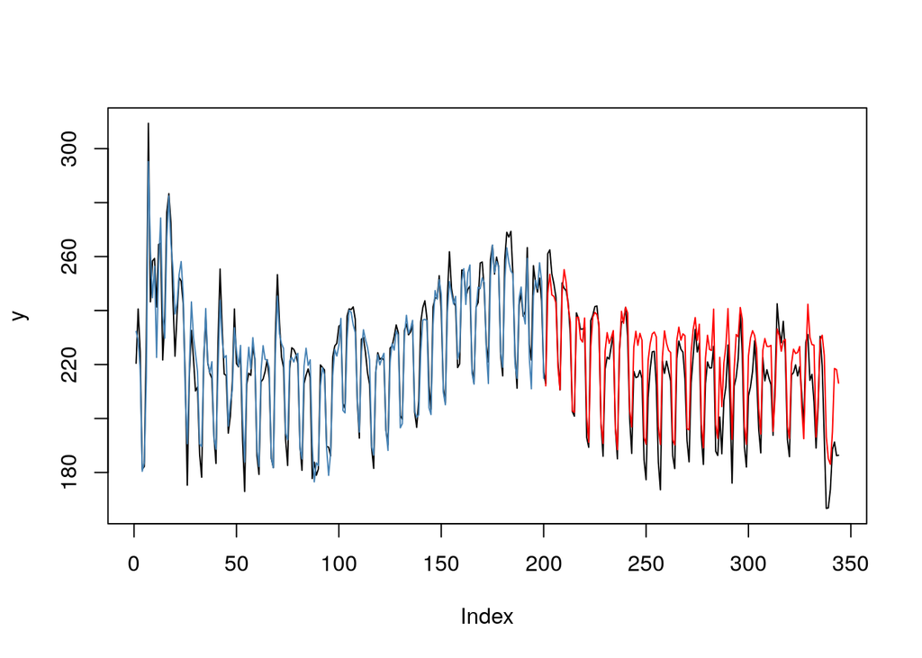

```r
preds2 <- predict_ts_cv.glmnet(object = fit, newx = xte, h = nrow(xte), lagvars = paste0("lag_", lags))

plot(y, type = "l")
lines(predict(fit, newx = xtr, "lambda.1se"), col = "steelblue")
lines(te,preds2, col = "red")
```

# Versuch 3 mit adaptiv lasso

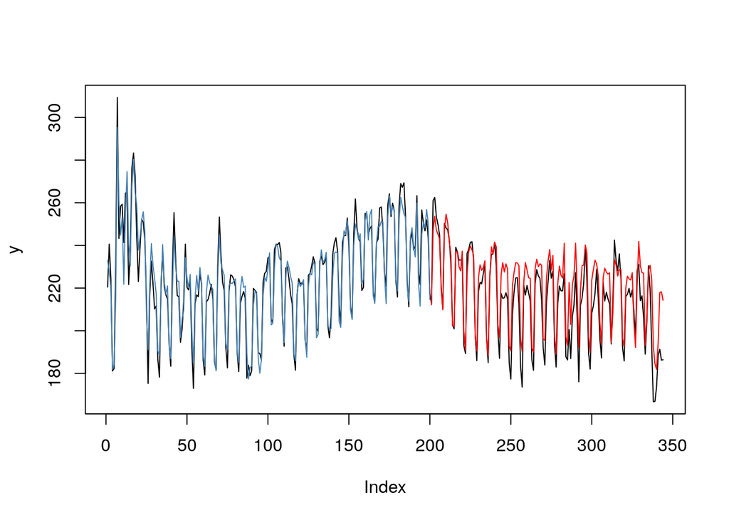

```r
y <- as.matrix(data[,1])
data$Temperature_sq <- data$Temperature^2
x <- as.matrix(data[,-1])

# train und test
tr <- 1:bis
te <- (bis+1):nrow(data)
ytr <- y[tr]
yte <- y[te]
xtr <- x[tr,]
xte <- x[te,]

# calculate weights
fit <- cv.glmnet(x = xtr, y = ytr, alpha = 0)
w <- abs(1/coef(fit, "lambda.1se")[-1])^.5

# fit and plot adaptive lasso mit quadratischen termen
fit <- cv.glmnet(x = xtr, y = ytr, alpha = 1, penalty.factor = w)
preds3 <- predict_ts_cv.glmnet(object = fit, newx = xte, h = nrow(xte), lagvars = paste0("lag_", lags))

plot(y, type = "l")
lines(predict(fit, newx = xtr, "lambda.1se"), col = "steelblue")
lines(te,preds3, col = "red")
```

# ranger

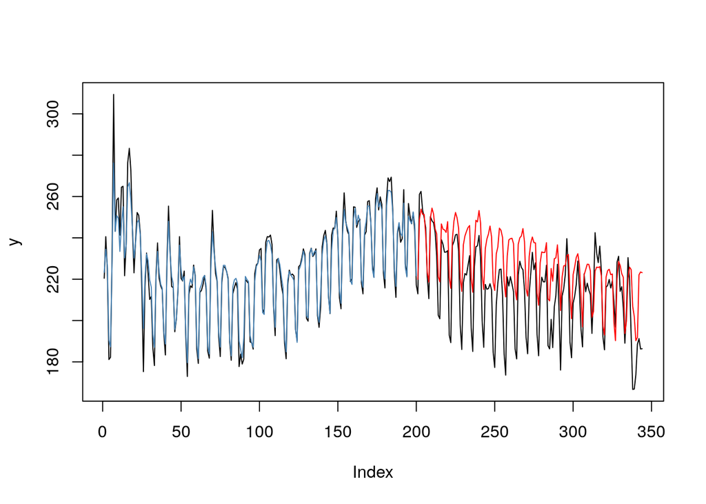

```r
data$Temperature_sq <- data$Temperature^2

# train und test
tr <- 1:bis
te <- (bis+1):nrow(data)
dat_tr <- data[tr,]
dat_te <- data[te,]


# fit ranger
library(ranger)
fit <- ranger(Demand ~ ., data = dat_tr)

# predict ranger iteratively into testset
predict_ts_ranger <- function(object, data, h, lagvars = paste0("lag_", 1:21), ...){
  if(!is.data.frame(data)) stop("data has to be a data.frame")
  preds <- numeric(h)
  for(k in 1:h){
    pre <- ranger:::predict.ranger(object = object, data = data[k,,drop = F])
    preds[k] <- pre$predictions
    lag_olddata <- data[k,lagvars]
    if(k<h)
    data[k+1,lagvars] <- c(preds[k], lag_olddata[-length(lag_olddata)])
  }
  return(preds)
}

preds_rf <- predict_ts_ranger(object = fit, data = dat_te, h = nrow(dat_te), lagvars = paste0("lag_", lags))

plot(y, type = "l")
lines(ranger:::predict.ranger(fit, data = dat_tr)$predictions, col = "steelblue")
lines(te,preds_rf, col = "red")
```

# visualler vergleich mit auto.arima und xreg

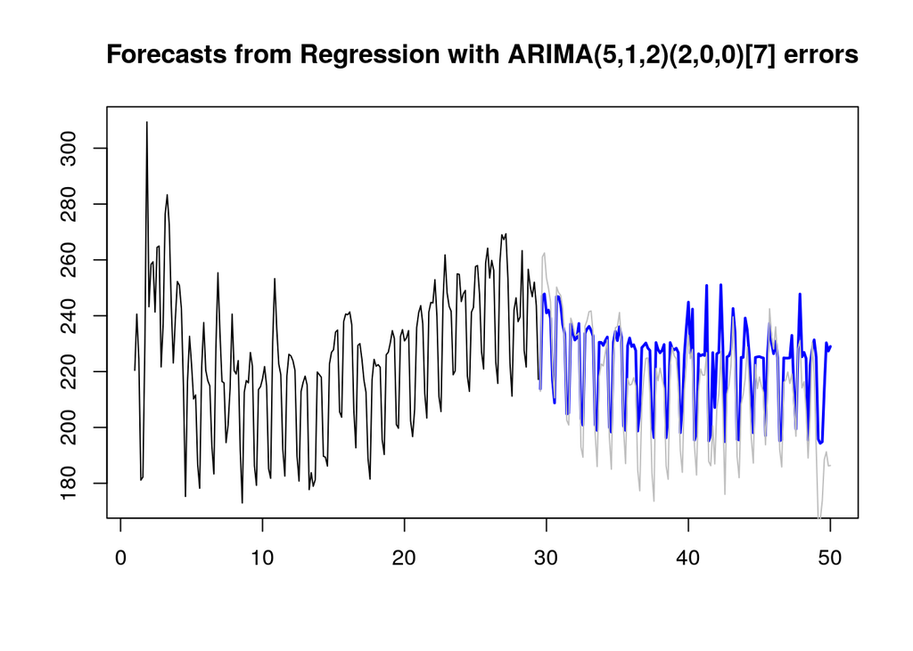

```r
yts <- ts(ytr, freq = 7)
fit <- auto.arima(yts, xreg = xtr[,c("WorkDay", "Temperature", "Temperature_sq")])
fc <- forecast(fit, h = nrow(xte), xreg = xte[,c("WorkDay", "Temperature", "Temperature_sq")])
plot(fc, PI =F)
lines(ts(yte, freq = 7, start = attr(yts, "tsp")[2]+1/7), col = "grey")
```

# MSE berechnen

```r
mse(yte, preds1)
```

```
## [1] 374.3243
```

```r
mse(yte, preds2)
```

```
## [1] 110.5979
```

```r
mse(yte, preds3)
```

```
## [1] 108.9781
```

```r
mse(yte, preds_rf)
```

```
## [1] 326.4365
```

```r
mse(yte, fc$mean)
```

```
## [1] 182.9087
```